# Transportation Trips County

Author

Tina Chelidze

Published

April 9, 2024

*2023-2024 Mobility Metrics update*

SUMMARY-LEVEL VALUES

Raw data pulled from https://htaindex.cnt.org/download/ The Housing and Transportation (H+T) Affordability Index from the Center for Neighborhood Technology (CNT)

*User Notice: This program requires downloading raw files from the Metrics_2024_round Box folder prior to running. See details under the Read Data section.*

## Housekeeping

Read in packages for use.

```r
library(tidyr)
library(dplyr)
library(ggplot2)
library(tidyverse)
library(purrr)
library(tidycensus)
```

## Read data

- htaindex2015_data_counties.csv
- htaindex2019_data_counties.csv

Import all the files (and/or combine into one file) with only the relevant variables and years

FOR COUNTIES - import the raw data files

Unlike for Places and Tracts, the CNT website allows you to download raw data for all counties at once so we just import the all-county file for the two available years; 2015 and 2019

### 2015

```r
transport_county_2015 <- read_csv(here::here("06_neighborhoods",
                                             "Transportation",
                                             "data",
                                             "htaindex2015_data_counties.csv"))
```

Create correct FIPS columns.

```r
transport_county_2015 <- transport_county_2015 %>%
  mutate(
    state = substr(county, start = 2, stop = 3),
    county = substr(county, start = 4, stop = 6)
  )
```

Keep only variables of interest

```r
transit_trips_county_2015 <- transport_county_2015 %>%
  select(state, county, blkgrps, population, households, transit_trips_80ami)
```

### 2019

```r
transport_county_2019 <- read_csv(here::here("06_neighborhoods",
                                             "Transportation",
                                             "data",
                                             "htaindex2019_data_counties.csv"))

transport_county_2019 <- transport_county_2019 %>%
  select(county, blkgrps, population, households, transit_trips_80ami)
```

Create correct FIPS columns

```r
transport_county_2019 <- transport_county_2019 %>%
  mutate(
    state = substr(county, start = 2, stop = 3),
    county = substr(county, start = 4, stop = 6)
  )
```

Keep only variables of interest

```r
transit_trips_county_2019 <- transport_county_2019 %>%
  select(state, county, blkgrps, population, households, transit_trips_80ami)
```

Compare to our official county file to make sure we have all counties accounted for Bring in the official county file

```r
counties <- read_csv(here::here("geographic-crosswalks",
                                "data",
                                "county-populations.csv"))
```

```r
counties_2015 <- counties %>%
  filter(year == 2015)

counties_2019 <- counties %>%
  filter(year == 2019)
```

All files have same number of observations (3142) so no merging needed to account for missings!

## Quality Control Checks

Create a histogram plot and summary stats for each dataframe check that all values are non-negative & count missing values examine outliers.

County-Level Transit Trips 2015

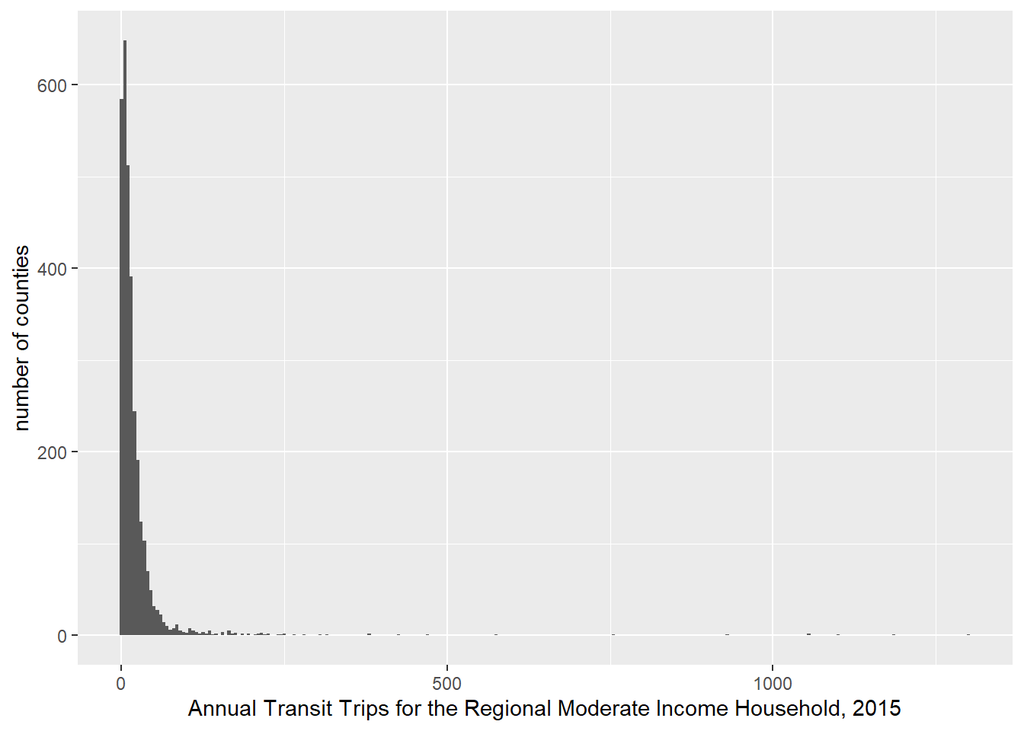

```r
ggplot(transit_trips_county_2015, aes(x=transit_trips_80ami)) + geom_histogram(binwidth=5) + labs(y="number of counties", x="Annual Transit Trips for the Regional Moderate Income Household, 2015")
```

Makes sense for most counties to fall in really low transit trip numbers since most of the US has no public infrastructure that can be used for daily transport

Look at summary stats

```r
summary(transit_trips_county_2015$transit_trips_80ami)
```

```
   Min. 1st Qu.  Median    Mean 3rd Qu.    Max.    NA's
   0.00    4.00   11.00   21.15   22.00 1300.00       1
```

Examine outliers

```r
transit_trips_county_2015_outliers <- transit_trips_county_2015 %>%
  filter(transit_trips_80ami>250)
```

Use stopifnot to check if all values in “transit_trips_county_2015” are non-negative

```r
stopifnot(min(transit_trips_county_2015$transit_trips_80ami, na.rm = TRUE) >= 0)
```

Good to go.

Find indices of missing values for the “transit_trips_80ami” variable.

```r
missing_indices <- which(is.na(transit_trips_county_2015$transit_trips_80ami))
```

Print observations with missing values.

```r
if (length(missing_indices) > 0) {
  cat("Observations with missing values for transit_trips_80ami:\n")
  print(transit_trips_county_2015[missing_indices, , drop = FALSE])
} else {
  cat("No missing values for transit_trips_county_2015.\n")
}
```

```
Observations with missing values for transit_trips_80ami:
# A tibble: 1 × 6
  state county blkgrps population households transit_trips_80ami
  <chr> <chr>    <dbl>      <dbl>      <dbl>               <dbl>
1 48    301          1        117         45                  NA
```

One missing value: Loving County, Texas (FIPS 48301).

County-Level Transit Trips 2019

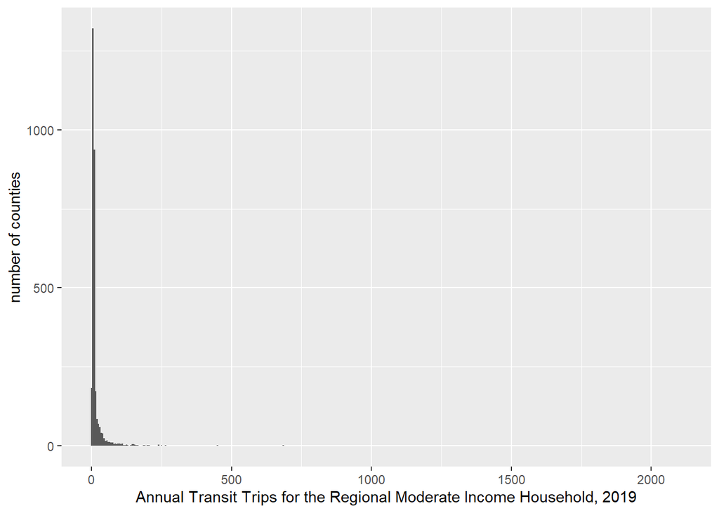

```r
ggplot(transit_trips_county_2019, aes(x=transit_trips_80ami)) + geom_histogram(binwidth=5) + labs(y="number of counties", x="Annual Transit Trips for the Regional Moderate Income Household, 2019")
```

Looks similar, checks out.

Look at summary stats.

```r
summary(transit_trips_county_2019$transit_trips_80ami)
```

```
   Min. 1st Qu.  Median    Mean 3rd Qu.    Max.
   0.00    6.00    8.00   21.76   11.00 2105.00
```

Examine outliers

```r
transit_trips_county_2019_outliers <- transit_trips_county_2019 %>%
  filter(transit_trips_80ami>250) %>%
  arrange(desc(transit_trips_80ami))
```

Use stopifnot to check if all values in “transit_trips_county_2019” are non-negative

```r
stopifnot(min(transit_trips_county_2019$transit_trips_80ami, na.rm = TRUE) >= 0)
```

Good to go

Find indices of missing values for the “transit_trips_80ami” variable

```r
missing_indices <- which(is.na(transit_trips_county_2019$transit_trips_80ami))
```

Print observations with missing values

```r
if (length(missing_indices) > 0) {
  cat("Observations with missing values for transit_trips_80ami:\n")
  print(transit_trips_county_2019[missing_indices, , drop = FALSE])
} else {
  cat("No missing values for transit_trips_county_2019\n")
}
```

```
No missing values for transit_trips_county_2019
```

No missing values for 2019.

### Create national percentile ranking for ‘transit_trips_80ami’

```r
transit_trips_county_2015 <- transit_trips_county_2015 %>%
  mutate(rank = rank(transit_trips_80ami),
         percentile_rank = (rank - 1) / (n() - 1) * 100,
         percentile_rank = round(percentile_rank, 2)) %>%
  rename(index_transit_trips = percentile_rank)

transit_trips_county_2019 <- transit_trips_county_2019 %>%
  mutate(rank = rank(transit_trips_80ami),
         percentile_rank = (rank - 1) / (n() - 1) * 100,
         percentile_rank = round(percentile_rank, 2)) %>%
  rename(index_transit_trips = percentile_rank)
```

## Data Quality Marker

Determine data quality cutoffs based on number of observations (all at the HH level for these values).

```r
summary(transit_trips_county_2015$households)
```

```
   Min. 1st Qu.  Median    Mean 3rd Qu.    Max.
     45    4232    9808   37214   25607 3263069
```

```r
summary(transit_trips_county_2019$households)
```

```
   Min. 1st Qu.  Median    Mean 3rd Qu.    Max.
     30    4268    9928   38433   26042 3316795
```

```r
transit_trips_county_2015 <- transit_trips_county_2015 %>%
  mutate(index_transit_trips_quality = ifelse(households > 30, 1, 3))

transit_trips_county_2019 <- transit_trips_county_2019 %>%
  mutate(index_transit_trips_quality = ifelse(households > 30, 1, 3))
```

## Export final files

Add a variable for the year of the data.

```r
transit_trips_county_2015 <- transit_trips_county_2015 %>%
  mutate(
    year = 2015
  )
transit_trips_county_2019 <- transit_trips_county_2019 %>%
  mutate(
    year = 2019
  )
```

Combine the two years into one overall file.

```r
transit_trips_county <- rbind(transit_trips_county_2015, transit_trips_county_2019)
```

Keep variables of interest and order them appropriately.

```r
transit_trips_county <- transit_trips_county %>%
  select(year, state, county, index_transit_trips, index_transit_trips_quality) %>%
  arrange(year, state, county, index_transit_trips, index_transit_trips_quality)
```

Save as non-subgroup all-year files.

```r
write_csv(transit_trips_county, here::here("06_neighborhoods",
                                           "Transportation",
                                           "final",
                                           "transit_trips_all_county.csv"))
```